# Aula 10 - Econometria de Séries Temporais

Autor

João Ricardo F. de Lima

Data de Publicação

9 de junho de 2025

# Análise de Séries Temporais Multivariadas

Na análise univariada de séries temporais o objetivo era, basicamente, entender a dependência dinâmica de uma série $X_{t}$, isto é, a dependência de $X_{t}$ com os seus valores passados $(X_{t-1}, X_{t-2},...)$.

Contudo, existem variáveis que são definidas dentro de um sistema e pode ser uma simplificação inadequada modelar estes processos de maneira puramente autorregressiva ou não controlando a dinâmica intertemporal: PIB, Consumo, Investimento, Gastos do Governo são definidos simultaneamente, por exemplo.

Essas questões, bastante pertinentes no dia a dia, são tratadas dentro da **análise multivariada de séries temporais**.

São objetivos básicos da análise multivariada de séries temporais:

1. Estudar as relações dinâmicas entre séries diversas;
2. Melhorar as previsões sobre uma variável específica.

Seja $z_{t} = (z_{1t}, z_{2t}, ..., z_{kt})^{'}$ um vetor de dimensão $k$ que contém séries temporais observadas em um período de tempo comum. Por exemplo, $z_{1t}$ é o PIB trimestral brasileiro e $z_{2t}$ é a taxa de desemprego também trimestral.

Estudando $z_{1t}$ e $z_{2t}$ conjuntamente, pode-se verificar a dependência contemporânea e passada que existe entre essas duas variáveis. Pode-se verificar o quanto um choque no PIB afeta a taxa de desemprego e quanto tempo isso tende a durar. Pode-se estar interessados na relação entre os desembolsos do BNDES e a taxa de investimento da economia brasileira. Será que aumentar os desembolsos ao banco eleva o investimento no país?

## Exemplo de séries que possuem correlação

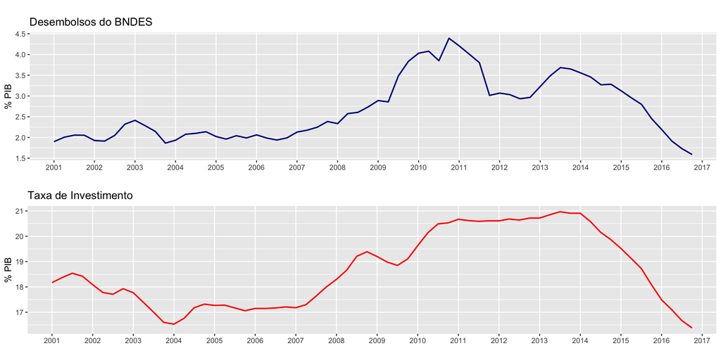

```r
library(vars)
library(aod)
library(urca)
library(stargazer)
library(forecast)
library(ggplot2)
#library(ggthemr)
library(gridExtra)
library(readxl)
library(scales)
#ggthemr('light')

# Os dados do BNDES estão em http://bit.ly/2pHg5wc. Depois de baixar e salvar na pasta correta, é importar os dados

setwd('/Users/jricardofl/Dropbox/tempecon/facape/econometria2')

data <- read_xls("bndes.xls", range = "AX5:AX264")
colnames(data) <- "desembolso"
data <- as.data.frame(data)

#Retira os valores faltantes
data <- na.omit(data)

#Retira os somatórios
data <- data[-c(13,13*2,13*3,13*4,13*5,13*6,13*7,13*8,13*9,13*10,13*11,
                13*12,13*13,13*14,13*15,13*16,13*17,13*18),]

data <- as.data.frame(data)

#Seta como série temporal
desembolso <- ts(data, start=c(2000,1), freq=12)

#Limita até o final de 2016
desembolso <- window(desembolso, end=c(2016,12))

anual <- desembolso
anual <- (anual+lag(anual,-1)+lag(anual,-2)+lag(anual,-3)+
              lag(anual,-4)+lag(anual,-5)+lag(anual,-6)+
              lag(anual,-7)+lag(anual,-8)+lag(anual,-9)+
              lag(anual,-10)+lag(anual,-11))
desembolso12 <- anual

# Dados do PIB e da taxa de investimento

data2 <- ts(read.csv2('data-1.csv', sep=';', dec=',')[,-1],
            start=c(1996,4), freq=4)

# Consolidando os dados
bndes <- ts(aggregate(desembolso12, nfrequency = 4, FUN=mean),
                start=c(2001,1), freq=4)

# Juntando as bases de dados
data <- ts.intersect(data2, bndes)
data <- cbind(data[,3]/data[,1]*100, data[,2])
colnames(data) <- c('BNDES', 'Investimento')

#Plot dos dois gráficos
g1 <- autoplot(data[,1])+
  geom_line(size=.8, colour='darkblue')+
  scale_x_discrete(limits=2001:2017)+
  labs(title='Desembolsos do BNDES')+
  xlab('')+ylab('% PIB')
g2 <- autoplot(data[,2])+
  geom_line(size=.8, colour='red')+
  scale_x_discrete(limits=2001:2017)+
  labs(title='Taxa de Investimento')+
  xlab('')+ylab('% PIB')
grid.arrange(g1, g2,
             top = "",
            layout_matrix = matrix(c(1,1,2,2),
                                   ncol=2, byrow=TRUE))
```

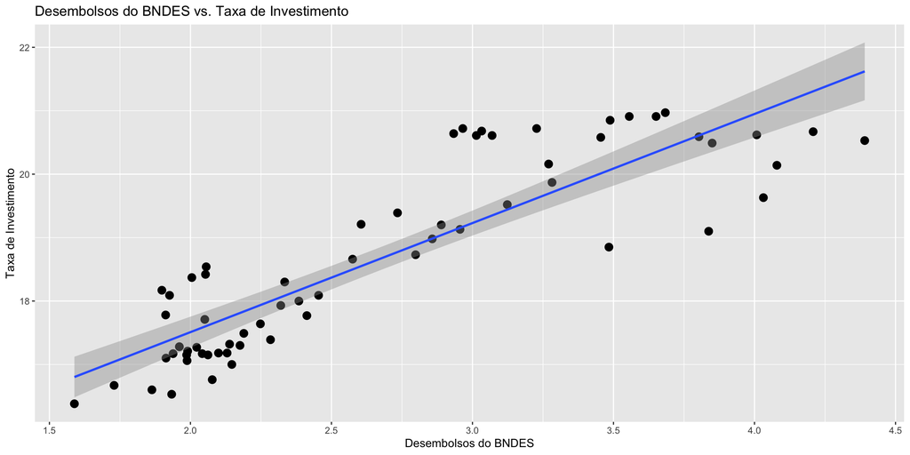

```r
# Correlação entre Desembolsos do BNDES vs. Taxa de Investimento
dates <- seq(as.Date('2001-01-01'), as.Date('2016-12-01'), by='3 month')
df <- data.frame(time=dates, bndes=data[,1], investimento=data[,2])
ggplot(df, aes(bndes, investimento))+
  geom_point(colour='black', size=5, shape=20)+
  geom_smooth(method = 'lm')+
  xlab('Desembolsos do BNDES')+
  ylab('Taxa de Investimento')+
  labs(title='Desembolsos do BNDES vs. Taxa de Investimento')
```

```r
cor(data)
```

```
                 BNDES Investimento
BNDES        1.0000000    0.8732192
Investimento 0.8732192    1.0000000
```

A correlação entre as variáveis é 0.87, bastante elevada.

## Modelos Multivariados

Contudo, não é o bastante para se identificar a natureza da relação entre elas. Algumas questões devem ser levadas em consideração. Suponha que as séries sejam estacionárias em nível. Pode-se, nesse caso, estimar um **Vetor Autoregressivo (VAR)** de primeira ordem, de modo que:

$$FBCF_{t} = \delta_{1} + \gamma_{11}FBCF_{t-1} + \gamma_{12}BNDES_{t-1} + \varepsilon_{1t}$$

$$BNDES_{t} = \delta_{2} + \gamma_{21}BNDES_{t-1} + \gamma_{22}FBCF_{t-1} + \varepsilon_{2t}$$

### O Modelo VAR

O VAR(1) vai descrever a evolução dinâmica da interação entre a FBCF e os desembolsos do BNDES.

O modelo VAR foi desenvolvido por Christopher Sims (em um artigo publicado em 1980), em que ele se propôs tratar todas as variáveis do sistema como endógenas e simétricas, evitando imposições ex-ante sobre causalidade estrutural.

Uma vez estimado esse modelo, pode-se perguntar se existe causalidade nessa relação, isto é, se os desembolsos do BNDES de fato ajudam a prever a taxa de investimento, se o contrário ocorre ou se há uma simultaneidade. Nesse último caso, diz-se que existe uma causalidade bidirecional.

Para definir o modelo VAR pode-se apresentar uma especificação bivariada simples. A idéia é que não sabendo se há causalidade mútua, se parte de um modelo em que as inovações contemporâneas (choques que ocorrem no mesmo momento do tempo — ou seja, os efeitos simultâneos entre as variáveis do sistema) de um processo afetam o outro.

$$y_{1,t}=\alpha_1-\delta_2y_{2,t}+\beta_1y_{1,t-1}+\beta_2y_{2,t-1}+\epsilon_{1,t}$$

$$y_{2,t}=\alpha_2-\delta_1y_{1,t}+\beta_2y_{2,t-1}+\beta_1y_{1,t-1}+\epsilon_{2,t}$$

No sistema acima, os termos $y_{1,t}$ e $y_{2,t}$ representam a dinâmica contemporânea, relaxando a hipótese de restrição de *feedback*. A restrição de feedback contemporâneo é uma hipótese comum em modelos univariados ou VARs na forma reduzida, onde se supõe que uma variável não pode ser afetada imediatamente (no mesmo período) por outra variável endógena. Ou seja, os efeitos acontecem apenas com defasagem.

O modelo acima está no denominado modelo estrutural, devido a presença do termo contemporâneo no lado direito de cada equação. A forma estrutural representa o sistema como ele funciona na realidade, incluindo relações simultâneas (contemporâneas) entre as variáveis.

Para colocá-lo na forma reduzida (a forma do modelo que pode ser diretamente estimada com os dados, onde os choques não estão correlacionados com as variáveis explicativas e não se tem os termos contemporâneos), se escreve o modelo na forma matricial a partir do rearranjo;

$$y_{1,t}+\delta_2y_{2,t}=\alpha_1+\beta_1y_{1,t-1}+\beta_2y_{2,t-1}+\epsilon_{1,t}$$

$$y_{2,t}+\delta_1y_{1,t}=\alpha_2+\beta_2y_{2,t-1}+\beta_1y_{1,t-1}+\epsilon_{2,t}$$

a partir do qual se obtém:

$$\left[\begin{array}{cc}
1 & \delta_2\\
\delta_1 & 1
\end{array}\right] \left[\begin{array}{c}
y_1 \\
y_2
\end{array}\right]_t = \left[\begin{array}{c}
\alpha_1\\
\alpha_2
\end{array}\right]+ \left[\begin{array}{cc}
\beta_1 & \beta_2 \\
\beta_2 & \beta_1
\end{array}\right] \left[\begin{array}{c}
y_1 \\
y_2
\end{array}\right]_{t-1}+\left[\begin{array}{c}
\epsilon_1 \\
\epsilon_2
\end{array}\right]_t$$

que pode ser simplificado como

$$Ay_t=\alpha+B^*y_{t-1}+\epsilon_t$$

De onde se obtém

$$y_t=a+By_{t-1}+e_t,$$

a chamada forma reduzida, em que $a=A^{-1}\alpha$, $B=A^{-1}B^*$ e $e_t=A^{-1}\epsilon_t$. Ela elimina os termos contemporâneos entre variáveis endógenas e é a forma que pode ser estimada diretamente com os dados. Os erros $e_t$ são combinações lineares dos choques estruturais, mas **não têm interpretação causal direta**.

No Modelo VAR todas as variáveis são consideradas endógenas e determinadas de forma dinâmica pelos valores defasados. Se tem uma equação para cada variável em função de seus valores defasados e dos valores defasados das outras variáveis.

Um VAR tem duas dimensões:

1. número de variáveis =k;
2. número de defasagens =p.

O estimador de MQO pode ser aplicado a cada equação individualmente.

### Estabilidade do Modelo VAR

Um modelo VAR precisa ser estável. A estabilidade de um modelo VAR está associada ao comportamento dinâmico do sistema: se as variáveis retornam ao equilíbrio após um choque. Caso o modelo não seja estável, suas previsões podem divergir ao longo do tempo, tornando a análise inútil do ponto de vista econômico.

A estabilidade é verificada pelas **raízes características** do modelo. Seja o modelo VAR(p):

$$y_t = B_1 y_{t-1} + B_2 y_{t-2} + \dots + B_p y_{t-p} + e_t$$

Define-se o **polinômio característico** como:

$$\Pi(z) = I - B_1 z - B_2 z^2 - \dots - B_p z^p$$

A **condição necessária e suficiente** para a estabilidade do VAR é que **todas as raízes do determinante $|\Pi(z)| = 0$ estejam fora do círculo unitário**, ou seja:

$$|z| > 1$$

Isso garante que a solução do sistema VAR possa ser representada como uma função convergente de choques passados:

$$y_t = \sum_{i=0}^{\infty} \Phi_i e_{t-i}$$

onde os coeficientes $\Phi_i$ vão decaindo ao longo do tempo.

**Importante**: modelos VAR estáveis são sempre estacionários. No entanto, o inverso nem sempre é verdadeiro — especialmente no caso de modelos com cointegração, em que há uma forma estacionária para combinações lineares das variáveis (VECM).

A verificação empírica das raízes pode ser feita com o comando `roots()` no R (pacote `vars`), que informa os módulos das raízes do polinômio $\Pi(z)$.

Este processo está simulado na figura abaixo:

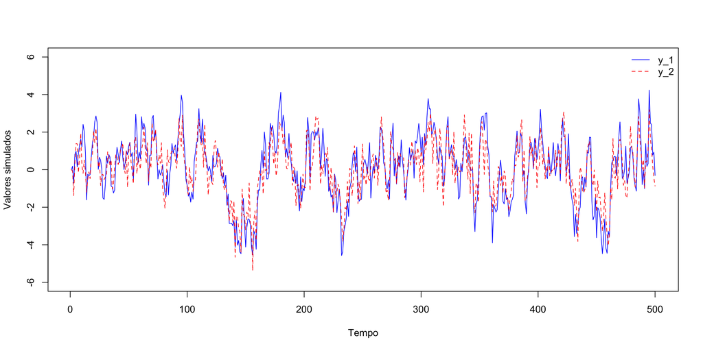

```r
# Simulação de um modelo VAR(1)
set.seed(1)

# Parâmetros
n <- 500         # Número de observações
r <- 0.7         # Correlação entre choques

# Geração de choques correlacionados
Z1 <- rnorm(n)
Z2 <- rnorm(n)
E1 <- Z1
E2 <- r * Z1 + sqrt(1 - r^2) * Z2

# Matriz de coeficientes A para o VAR(1)
A <- matrix(c(0.7, 0.2,
              0.4, 0.3), nrow = 2, byrow = TRUE)

# Inicialização das séries
y_1 <- y_2 <- numeric(n)

# Geração das séries
for (t in 2:n) {
  y_1[t] <- A[1,1] * y_1[t-1] + A[1,2] * y_2[t-1] + E1[t]
  y_2[t] <- A[2,1] * y_1[t-1] + A[2,2] * y_2[t-1] + E2[t]
}

# Gráfico das séries simuladas
plot(y_1, type = "l", col = "blue", ylim = c(-6, 6),
     ylab = "Valores simulados", xlab = "Tempo")
lines(y_2, col = "red", lty = 2)
legend("topright", legend = c("y_1", "y_2"),
       col = c("blue", "red"), lty = c(1, 2), bty = "n")
```

Estes processos apresentam dinâmica comum. É dito estável.

Para obter um processo não estável basta que as raízes sejam unitárias:

$$\left[\begin{array}{c}
y_1 \\
y_2
\end{array}\right]_t = \left[\begin{array}{cc}
1 & 0 \\
0 & 1
\end{array}\right] \left[\begin{array}{c}
y_1 \\
y_2
\end{array}\right]_{t-1}+\left[\begin{array}{c}
\epsilon_1 \\
\epsilon_2
\end{array}\right]_t$$

Este processo está simulado na figura abaixo:

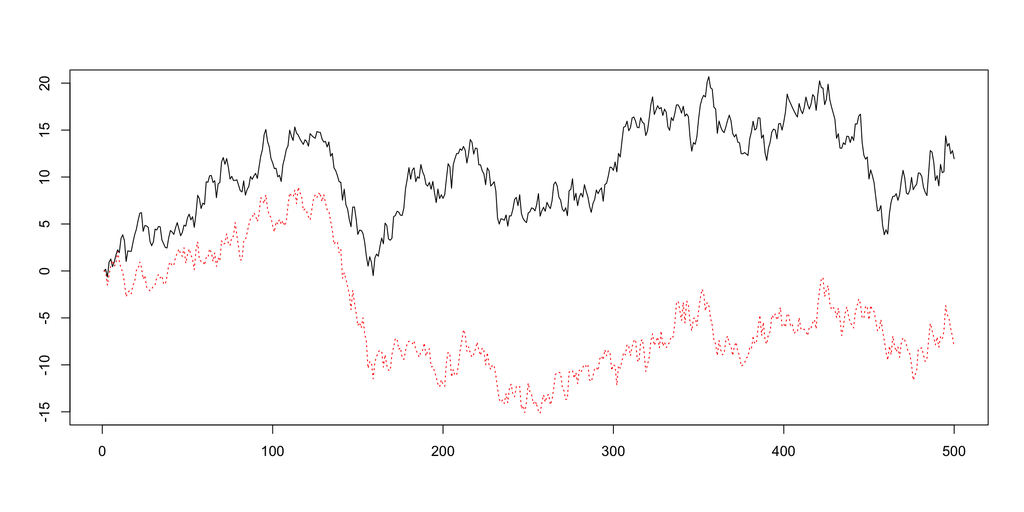

```r
# A outra  matriz "A" abaixo gera o processo do sistema (8.14).

A = matrix(c(1,0,0,1),2,2)

y_3 = y_4 <- rep(0,n)

for(t in 2:n){
   y_3[t] <- A[1,1]*y_3[t-1] + A[1,2]*y_4[t-1] + E1[t]
   y_4[t] <- A[2,1]*y_3[t-1] + A[2,2]*y_4[t-1] + E2[t]
}

# # Figura 8.2
plot(y_3, type = "l", lty = 1, ylim = c(-15,20), ann = FALSE)
 lines(y_4,lty = 3, col = "red")
```

Estes processos não apresentam dinâmica comum, tendem a se descolar. É dito instável.

### Determinação da Ordem de Defasagem

Uma vez que temos nossos dados devidamente tratados, o próximo passo é determinar a ordem $p$ de defasagem do modelo VAR. Essa escolha é feita com base em **critérios de informação**, que equilibram a qualidade do ajuste do modelo com sua complexidade.

Os critérios mais utilizados são:

- **AIC** (Critério de Akaike)
- **HQ** (Critério de Hannan-Quinn)
- **SC** (Critério de Schwarz ou BIC)

Esses critérios são calculados da seguinte forma:

$$AIC(p) = \log \det (\Sigma_{u}(p)) + \frac{2}{T} p K^{2}$$

$$HQ(p) = \log \det (\Sigma_{u}(p)) + \frac{2 \log(\log(T))}{T} p K^{2}$$

$$SC(p) = \log \det (\Sigma_{u}(p)) + \frac{\log(T)}{T} p K^{2}$$

onde:

- $\Sigma_u(p) = \frac{1}{T} \sum_{t=1}^{T} \hat{u}_t \hat{u}_t'$ é a matriz de variância-covariância dos resíduos estimados;
- $K$ é o número de variáveis do sistema VAR;
- $T$ é o número de observações (ajustado pelas defasagens utilizadas).

Em termos práticos: quanto menor o valor do critério, melhor o modelo segundo esse critério.

No R, esses critérios estão implementados na função `VARselect()` do pacote `vars`, conforme o exemplo abaixo:

A determinação do lag é dada por:

```r
# Estruturação dados com como um objeto "ts" e ajuste em um modelo VAR.
data <- as.ts(cbind(y_1,y_2))

# Estimação da número de lags e do processo
VARselect(data, lag.max = 6, type = "none")
```

```
$selection
AIC(n)  HQ(n)  SC(n) FPE(n)
     1      1      1      1

$criteria
                1          2          3          4          5          6
AIC(n) -0.5272731 -0.5228150 -0.5121428 -0.5034198 -0.4932275 -0.4905418
HQ(n)  -0.5139134 -0.4960957 -0.4720639 -0.4499812 -0.4264292 -0.4103839
SC(n)  -0.4932445 -0.4547577 -0.4100569 -0.3673053 -0.3230843 -0.2863700
FPE(n)  0.5902123  0.5928498  0.5992117  0.6044634  0.6106591  0.6123063
```

A primeira parte da saída indica o número ótimo de defasagens para cada critério, seguido pela tabela com o valor de cada um para cada defasagem. A melhor defasagem é dada pelo menor valor do critério. Isto é tudo que se precisa para estimar um modelo VAR.

### Estimação do Modelo VAR(1)

O modelo VAR (1) estimado pelo método dos Mínimos Quadrados Ordinários é:

```r
# Estruturação dados com como um objeto "ts" e ajuste em um modelo VAR.
(model1 <- VAR(data, p = 1, type = "none"))
```

```
VAR Estimation Results:
=======================

Estimated coefficients for equation y_1:
========================================
Call:
y_1 = y_1.l1 + y_2.l1

   y_1.l1    y_2.l1
0.6804918 0.1867103


Estimated coefficients for equation y_2:
========================================
Call:
y_2 = y_1.l1 + y_2.l1

   y_1.l1    y_2.l1
0.4112754 0.2308376
```

O resultado da estimação apresenta uma equação para cada variável do sistema:

#### Equação para `$y_1$`:

$$\hat{y}_{1,t} = 0{,}6805 \cdot y_{1,t-1} + 0{,}1867 \cdot y_{2,t-1} + \hat{u}_{1,t}$$

#### Equação para `$y_2$`:

$$\hat{y}_{2,t} = 0{,}4113 \cdot y_{1,t-1} + 0{,}2308 \cdot y_{2,t-1} + \hat{u}_{2,t}$$

Os coeficientes estimados são próximos dos valores verdadeiros utilizados na simulação, que foram:

$$A_{\text{simulado}} =
\begin{bmatrix}
0{,}7 & 0{,}2 \\
0{,}4 & 0{,}3
\end{bmatrix}$$

Isso mostra que o estimador dos Mínimos Quadrados Ordinários (MQO), aplicado a cada equação do sistema, recupera bem os parâmetros populacionais em uma amostra grande.

Abaixo são apresentados os testes de autocorrelação, o de heterocedasticidade e os autovalores para verificar a estabilidade.

```r
# Diagnóstico

serial.test(model1)
```

```
    Portmanteau Test (asymptotic)

data:  Residuals of VAR object model1
Chi-squared = 71.339, df = 60, p-value = 0.15
```

```r
arch.test(model1)
```

```
    ARCH (multivariate)

data:  Residuals of VAR object model1
Chi-squared = 39.511, df = 45, p-value = 0.703
```

```r
vars::roots(model1)
```

```
[1] 0.81250724 0.09882218
```

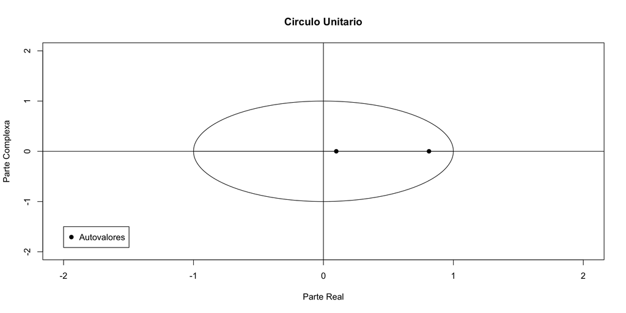

```r
# guardar autovalores do processo
autoval <- vars::roots(model1)

# Figura
x <- seq(-1,1,length = 1000)
y1 <- sqrt(1-x^2)
y2 <- -sqrt(1-x^2)
plot(c(x,x),c(y1,y2),xlab='Parte Real',ylab='Parte Complexa',type='l',main='Circulo Unitario',ylim=c(-2,2),xlim=c(-2,2))
abline(h = 0)
abline(v = 0)
points(autoval, Im(autoval),pch=19)
legend(-2.0,-1.5,legend="Autovalores",pch=19)
```

Como o p-valor é maior que 0,05, não rejeita-se a hipótese nula de ausência de autocorrelação dos resíduos. Ou seja, os resíduos se comportam como ruído branco — o modelo parece bem ajustado nesse aspecto.

O p-valor alto indica que não há evidência de heterocedasticidade nos resíduos — ou seja, as variâncias dos erros parecem constantes ao longo do tempo.

Sobre a estabilidade, como ambas raízes estão dentro do círculo unitário (isto é, $<1$), o modelo VAR(1) é estável, e suas soluções convergem com o tempo. Isso garante que a dinâmica do sistema converge ao longo do tempo e permite realizar previsões e análise de impulso-resposta com segurança.

### Função Impulso Resposta

Como visto, a modelagem VAR procura identificar a relação dinâmica existente em um conjunto previamente definido de variáveis. Dentro dessa estrutura, é possível analisar o efeito de um **choque** em uma variável sobre as demais.

Esse exercício é conhecido como **análise de impulso-resposta**. A ideia é verificar a resposta da variável $y_{i,t+s}$ a uma mudança unitária (impulso) em $y_{j,t}$. Em outra palavras, aplica-se um choque de uma unidade em $y_j$ no tempo $t$ e observa-se a trajetória de resposta de $y_i$ ao longo do tempo $t+s$.

Considere novamente o sistema:

$$y_{1,t} = \alpha_1 - \delta_2 y_{2,t} + \beta_1 y_{1,t-1} + \beta_2 y_{2,t-1} + \epsilon_{1,t}$$

$$y_{2,t} = \alpha_2 - \delta_1 y_{1,t} + \beta_2 y_{2,t-1} + \beta_1 y_{1,t-1} + \epsilon_{2,t}$$

Esse sistema pode ser reescrito na forma de médias móveis:

$$y_t = \bar{y} + \sum_{i=0}^{\infty} \Phi_i \epsilon_{t-i}$$

Onde $\Phi_i$ são as matrizes contendo os coeficientes de impulso-resposta:

$$\Phi_i =
\begin{bmatrix}
\phi_{1,1}(i) & \phi_{1,2}(i) \\
\phi_{2,1}(i) & \phi_{2,2}(i)
\end{bmatrix}$$

Cada elemento $\phi_{i,j}(s)$ representa o efeito de um choque unitário na variável $j$ no tempo $t$ sobre a variável $i$ no tempo $t + s$.

O valor $\phi_{i,j}(0)$ representa o **efeito imediato** (resposta contemporânea), e é conhecido como o **multiplicador de impacto**.

Se o modelo for estável, as respostas ao choque devem convergir para zero com o passar do tempo.

Na prática, os gráficos de impulso-resposta são usados para visualizar essas respostas, e cada linha do gráfico representa a sequência:

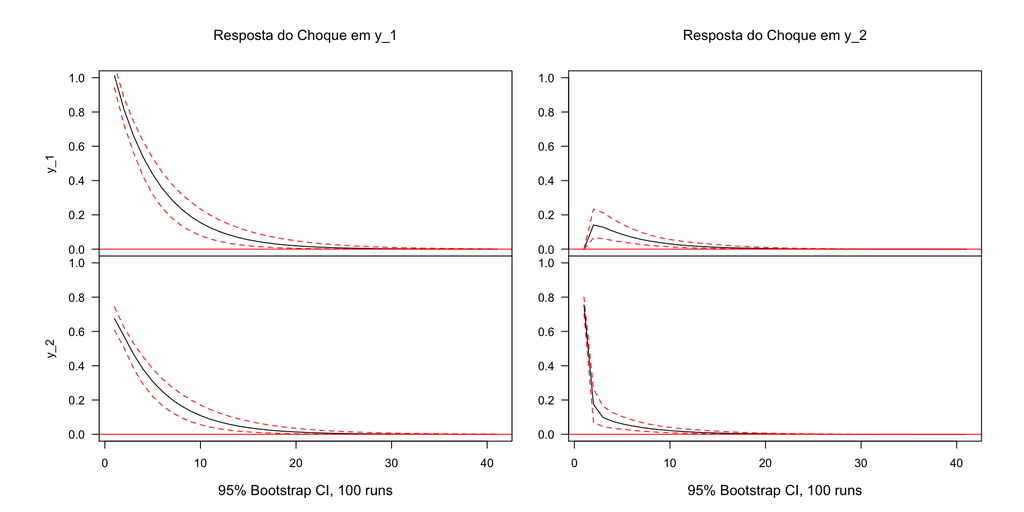

```r
# Função impulso-resposta
# FIR, PREVISAO E DECOMPOSICAO

# Elaboração da Figura

# resposta do choque em y1
model1.irf <- irf(model1, impulse = "y_1", n.ahead = 40, boot = TRUE)
# resposta do choque em y2
model2.irf <- irf(model1, impulse = "y_2", n.ahead = 40, boot = TRUE)

par(mfcol=c(2,2), mar=c(0,4,0,0), oma=c(5,3,5,3))

# Figura (a)
plot.ts(model1.irf$irf$y_1[,1], axes=F, oma.multi = c(0,0,5,0),
        ylab='y_1', ylim=c(-0,1))
lines(model1.irf$Lower$y_1[,1], lty=2, col='red')
lines(model1.irf$Upper$y_1[,1], lty=2, col='red')
axis(side=2, las=2, ylab='')
abline(h=0, col='red')
box()
mtext("Resposta do Choque em y_1", line = 2)

plot.ts(model1.irf$irf$y_1[,2], axes=F, oma.multi = c(0,0,5,0),
        ylab='y_2', ylim=c(-0,1))
lines(model1.irf$Lower$y_1[,2], lty=2, col='red')
lines(model1.irf$Upper$y_1[,2], lty=2, col='red')
axis(side=1, las=1)
axis(side=2, las=2)
abline(h=0, col='red')
box()
mtext("95% Bootstrap CI, 100 runs", side=1, line = 3)

# Figura (b)
plot.ts(model2.irf$irf$y_2[,1], axes=F, oma.multi = c(0,0,5,0),
        ylab='', ylim=c(-0,1))
lines(model2.irf$Lower$y_2[,1], lty=2, col='red')
lines(model2.irf$Upper$y_2[,1], lty=2, col='red')
axis(side=2, las=2, ylab='')
abline(h=0, col='red')
box()
mtext("Resposta do Choque em y_2", line = 2)

plot.ts(model2.irf$irf$y_2[,2], axes=F, oma.multi = c(0,0,5,0),
        ylab='', ylim=c(-0,1))
lines(model2.irf$Lower$y_2[,2], lty=2, col='red')
lines(model2.irf$Upper$y_2[,2], lty=2, col='red')
axis(side=1, las=1)
axis(side=2, las=2)
abline(h=0, col='red')
box()
mtext("95% Bootstrap CI, 100 runs", side=1, line = 3)
```

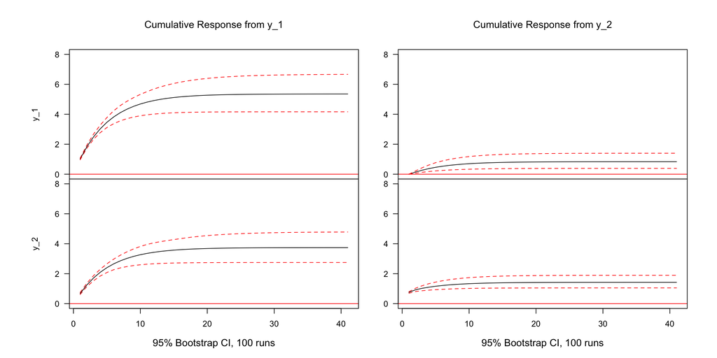

```r
# Elaboração da Figura

# resposta do choque em y1
model1.irf <- irf(model1, impulse = "y_1", n.ahead = 40, boot = TRUE, cumulative = T)
# resposta do choque em y2
model2.irf <- irf(model1, impulse = "y_2", n.ahead = 40, boot = TRUE, cumulative = T)

par(mfcol=c(2,2), mar=c(0,4,0,0), oma=c(5,3,5,3))

# Figura (a)
plot.ts(model1.irf$irf$y_1[,1], axes=F, oma.multi = c(0,0,5,0),
        ylab='y_1', ylim=c(-0,8))
lines(model1.irf$Lower$y_1[,1], lty=2, col='red')
lines(model1.irf$Upper$y_1[,1], lty=2, col='red')
axis(side=2, las=2, ylab='')
abline(h=0, col='red')
box()
mtext("Cumulative Response from y_1", line = 2)

plot.ts(model1.irf$irf$y_1[,2], axes=F, oma.multi = c(0,0,5,0),
        ylab='y_2', ylim=c(-0,8))
lines(model1.irf$Lower$y_1[,2], lty=2, col='red')
lines(model1.irf$Upper$y_1[,2], lty=2, col='red')
axis(side=1, las=1)
axis(side=2, las=2)
abline(h=0, col='red')
box()
mtext("95% Bootstrap CI, 100 runs", side=1, line = 3)

# Figura (b)
plot.ts(model2.irf$irf$y_2[,1], axes=F, oma.multi = c(0,0,5,0),
        ylab='', ylim=c(-0,8))
lines(model2.irf$Lower$y_2[,1], lty=2, col='red')
lines(model2.irf$Upper$y_2[,1], lty=2, col='red')
axis(side=2, las=2, ylab='')
abline(h=0, col='red')
box()
mtext("Cumulative Response from y_2", line = 2)

plot.ts(model2.irf$irf$y_2[,2], axes=F, oma.multi = c(0,0,5,0),
        ylab='', ylim=c(-0,8))
lines(model2.irf$Lower$y_2[,2], lty=2, col='red')
lines(model2.irf$Upper$y_2[,2], lty=2, col='red')
axis(side=1, las=1)
axis(side=2, las=2)
abline(h=0, col='red')
box()
mtext("95% Bootstrap CI, 100 runs", side=1, line = 3)
```

### Interpretação do Gráfico de Impulso-Resposta

O gráfico apresenta as respostas dinâmicas das variáveis $y_1$ e $y_2$ a choques unitários em cada uma delas.

- Um **choque em $y_1$** gera forte resposta imediata em $y_1$, com decaimento gradual (característica de um processo autoregressivo com inércia).
- Esse choque também afeta positivamente $y_2$, com efeito significativo no curto prazo.
- Um **choque em $y_2$** afeta a própria variável com impacto menor e mais transitório.
- Esse mesmo choque impacta $y_1$ de forma moderada e de curta duração.

A análise mostra que $y_1$ exerce maior influência sobre $y_2$ do que o contrário, sugerindo assimetria na relação dinâmica entre as variáveis.

No caso da função impulso resposta acumulada, mostra o efeito total acumulado de um choque ao longo do tempo. Enquanto a FIR normal mostra o impacto em cada período, a acumulada mostra a soma dos efeitos até aquele ponto no tempo.

A interpretação diz que a) Um **choque em $y_1$** tem Efeito acumulado de cerca de **5 unidades sobre $y_1$** e Efeito acumulado de cerca de **4 unidades sobre $y_2$**.

Isso indica que $y_1$ tem **impacto persistente e relevante** sobre o sistema como um todo.

2. Um **choque em $y_2$** tem Efeito acumulado de cerca de **1 unidade sobre $y_1$** e Efeito acumulado de cerca de **1,5 unidade sobre $y_2$**.

Assim, $y_2$ afeta as variáveis com **menor intensidade e persistência**.

Em sistemas VAR estáveis, as respostas acumuladas tendem a se estabilizar ao longo do tempo. Isso é o que observamos no gráfico: os efeitos crescem rapidamente nos primeiros períodos e se estabilizam após cerca de 20 períodos.

### Decomposição da variância

Um último tópico importante é a decomposição de variância, isto é, o quanto da variância de uma variável do nosso conjunto é explicado pelas demais variáveis. No R, ela é implementada com a função `fevd`.

Em linhas gerais, a função retorna o quanto a variação (percentual) do erro de previsão é atribuída a cada variável para uma sequencia de valores no tempo.

A variância total dos erros de previsão é decomposta em duas componentes, neste caso em análise, uma relacionada com $y_1$ e a outra com $y_2$.

Na prática, esta análise nos ajuda a verificar quais variáveis são realmente importantes quando o objetivo é realizar previsões.

Quanto maior for a contribuição percentual de uma variável para a variação total da outra, mais importante ela é para se realizar boas previsões da variável da qual realiza-se a decomposição.

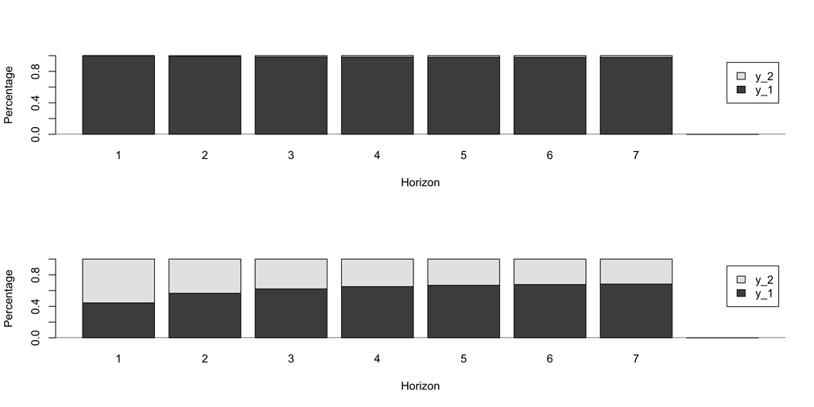

```r
# Decomposição da variância

fevd.model1 <- fevd(model1, n.ahead = 7)
plot(fevd.model1, main="")
```

- Para a variável $y_1$:
  - Praticamente **100% da variância do erro de previsão** é explicada por choques em $y_1$ ao longo de todo o horizonte.
  - Isso indica que $y_1$ é altamente autoregressiva e praticamente **independente de $y_2$**.
- Para a variável $y_2$:
  - Inicialmente, $y_2$ explica a maior parte de sua própria variância.
  - Com o passar do tempo, a **importância dos choques em $y_1$ aumenta**, chegando a representar mais da metade da variância de $y_2$.
  - Isso reforça que $y_1$ **tem um papel dominante** na dinâmica do sistema.

A Decomposição da variância é uma ferramenta complementar à análise de impulso-resposta, pois permite quantificar a importância relativa de cada variável no comportamento futuro das demais.

## Previsão no Modelo VAR

No R, duas maneiras para gerar previsões estão implantadas em predict() e fanchart(), a primeira retorna os pontos médios dos intervalos de confiança para cada previsão enquanto a segunda produz os intervalos como áreas sombreadas.

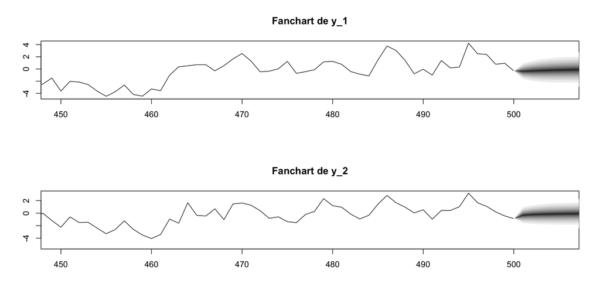

```r
# Previsões

#  previsão a partir de 'fanchart'
model1.y_1 <- predict(model1, n.ahead = 10, ci = 0.95)
fanchart(model1.y_1, xlim = c(450,505), main = c("Fanchart de y_1", "Fanchart de y_2"))
```

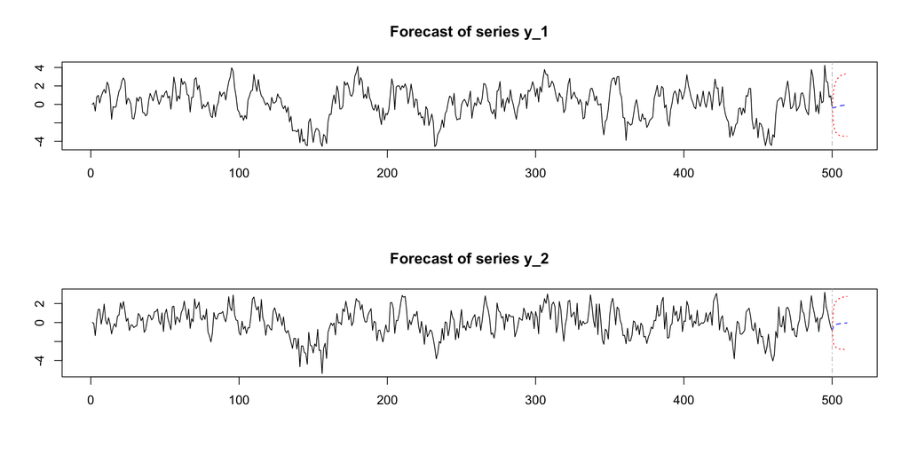

```r
plot(model1.y_1)
```

## Teste de Causalidade de Granger

O termo “causalidade de Granger” significa que há uma relação de antecedência-defasagem entre as variáveis de séries de tempo multivariadas. Em outras palavras, uma variável x vai ser dita que causa Granger em uma variável y, se os valores passados de x e valores passados de y forem úteis para prever y.

Testa se uma variável endógena pode ser tratada como exógena. Para cada equação do VAR, é calculado uma estatística de $\chi^2$ para a significância conjunta de cada uma das variáveis endógenas defasadas na equação.

A estimação do VAR deve ser feita antes do teste de causalidade de Granger, uma vez que a análise está verificando a causalidade entre várias variáveis.

Testa-se a hipótese nula de que os coeficientes estimados da variável exogena defasada são conjuntamente iguais à zero. Não rejeitar essa possibilidade é equivalente a não rejeitar a hipótese de que a variável Y não causa a Granger a variável X.

São estimadas regressões bivariadas na forma:

$$y_t=\alpha_{0}+\alpha_{1}y_{t-1}+\dots+\beta_1x_{t-1}+\dots+\varepsilon_t$$

$$x_t=\alpha_{0}+\alpha_{1}x_{t-1}+\dots+\beta_1y_{t-1}+\dots+\mu_t$$
para todos os possíveis pares de variáveis endógenas. O teste realizado conjuntamente, para cada equação, é:

$$\beta_1=\beta_2=\dots=0$$

As hipóteses nulas são que x não causa a Granger y na primeira equação e que y não causa a Granger x na segunda regressão.

```r
# Causalidade de Granger
causality(model1)$Granger
```

```
    Granger causality H0: y_1 do not Granger-cause y_2

data:  VAR object model1
F-Test = 70.104, df1 = 1, df2 = 994, p-value = 2.22e-16
```

## Exemplo Análise Macro I

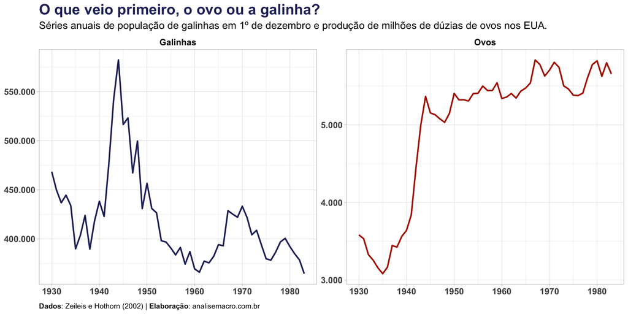

```r
# https://analisemacro.com.br/data-science/o-ovo-ou-a-galinha-teste-de-causalidade-de-granger-na-granja
# Causalidade de Granger

# Pacotes ---------

# Carregar pacotes
library(lmtest)
library(magrittr)
library(dplyr)
library(tidyr)
library(ggplot2)
library(scales)
library(ggtext)
library(purrr)
library(forecast)
library(tsibble)
library(downloader)


# Dados ---------

# Dataset de ovos/galinhas (veja documentação ?lmtest::ChickEgg)
dados <- lmtest::ChickEgg
dados_tbl <- dados %>%
  dplyr::as_tibble() %>%
  dplyr::mutate(
    date = seq(from = tsp(dados)[1], to = tsp(dados)[2], by = tsp(dados)[3])
    )

# Visualização dos dados
dados_tbl %>%
  tidyr::pivot_longer(cols = -"date") %>%
  dplyr::mutate(
    name = dplyr::recode(name, "chicken" = "Galinhas", "egg" = "Ovos")
    ) %>%
  ggplot2::ggplot() +
  ggplot2::aes(x = date, y = value, color = name) +
  ggplot2::geom_line(size = 1, show.legend = FALSE) +
  ggplot2::facet_wrap(facets = ~name, scales = "free") +
  ggplot2::scale_y_continuous(
    labels = scales::label_number(big.mark = ".", decimal.mark = ",")
    ) +
  ggplot2::scale_color_manual(values = c("#282f6b", "#b22200")) +
  ggplot2::labs(
    title    = "O que veio primeiro, o ovo ou a galinha?",
    subtitle = "Séries anuais de população de galinhas em 1º de dezembro e produção de milhões de dúzias de ovos nos EUA.",
    y        = NULL,
    x        = NULL,
    caption  = "**Dados**: Zeileis e Hothorn (2002) | **Elaboração**: analisemacro.com.br"
    ) +
  ggplot2::theme_light() +
  ggplot2::theme(
    plot.title       = ggplot2::element_text(size = 20, face = "bold", color = "#282f6b"),
    plot.subtitle    = ggplot2::element_text(size = 14),
    plot.caption     = ggtext::element_textbox_simple(size = 10, margin = ggplot2::margin(10)),
    axis.text        = ggplot2::element_text(size = 12, face = "bold"),
    strip.background = ggplot2::element_blank(),
    strip.text       = ggplot2::element_text(size = 12, face = "bold", color = "black")
    )
```

```r
# Número de diferenças para tornar a série estacionária----------------------------
dados_tbl <- tsibble::as_tsibble(dados_tbl, index = date)

feasts::unitroot_ndiffs(dados_tbl$chicken)
```

```
ndiffs
     1
```

```r
feasts::unitroot_ndiffs(dados_tbl$egg)
```

```
ndiffs
     1
```

```r
# 3) Diferencia as séries
dados_chk_diff <- diff(dados_tbl$chicken)
dados_egg_diff <- diff(dados_tbl$egg)

dados_diff <- cbind(dados_chk_diff, dados_egg_diff)

dados_diff <- ts(
  data      = dados_diff,
  start     = 1931,
  frequency = 1
  )


# Teste de causalidade de Granger -----------------------------------------

# Aplicar o teste de Causalidade de Granger
# H0: série X não Granger-causa série Y
# H1: série X Granger-causa série Y
lmtest::grangertest(
  y     = dados_diff[, "dados_chk_diff"],
  x     = dados_diff[, "dados_egg_diff"],
  order = 4 # lags/defasagens, de 1:5 resultados são similares
  )
```

|  | Res.Df | Df | F | Pr(>F) |
| --- | --- | --- | --- | --- |
| 1 | 40 | NA | NA | NA |
| 2 | 44 | -4 | 4.17622 | 0.006413988 |

```r
# p-valor deu 0.006414 -> hipótese nula rejeitada a 1% (há precedência temporal,
# série X causa no sentido de Granger série Y ou "ovos precedem galinhas")
```

```r
# Teste em reverso
lmtest::grangertest(
  y     = dados_diff[, "dados_egg_diff"],
  x     = dados_diff[, "dados_chk_diff"],
  order = 4
  )
```

|  | Res.Df | Df | F | Pr(>F) |
| --- | --- | --- | --- | --- |
| 1 | 40 | NA | NA | NA |
| 2 | 44 | -4 | 0.2816616 | 0.8881254 |

```r
# p-valor deu 0.8881 -> falha-se em rejeitar a hipótese nula (não há precedência temporal,
# série X não causa no sentido de Granger a série Y ou "galinhas não precedem ovos")
```